# Preprocessing

Joan Ginard

27 de mayo, 2023

```r
library(tidyverse)
library(patchwork)
source("helper_functions.R") #<- Defined functions like load data or filtering matrices
```

In this R Markdown file, we will execute all necessary preprocessing steps required to apply graph measures to our data. The notable exception is data harmonization, which will be carried out in a separate Python notebook. This is because we will be utilizing a library that is specifically written in Python.

For this purpose we have defined some functions in a separate R file called “helper_functions.R” which will also come in handy in later stages.

## LOAD CLINICAL DATA AND FILES LISTS

```r
## FOLDERS NAMES

dataDIR <- "data/"
FADIR <- "subjects_FA/"
fMRIDIR <- "subjects_fMRI/"
GMDIR <- "subjects_GM/"

# We define the "append" of matrices in each folder
FA_append <- "_FA_factor.csv"
fMRI_append <- "_r_matrix.csv"
GM_append <- "_GM_matrix.csv"

## Load clinical data

clinical <- read.csv(file.path(dataDIR, "clinic.csv"))[, c("id", "controls_ms", "age", "sex")] #We load only a few columns
```

We proceed to load the matrix files, verifying the presence of any patients without corresponding matrices, or conversely, matrices without associated patients. Any such inconsistent files are then discarded.

```r
# function filter_patients defined in helper_functions.R

cat(paste("####FA#####\n"))
```

```
## ####FA#####
```

```r
FA_files <- filter_patients(FADIR, FA_append, clinical, verbose = T)
```

```
## Cheking data...
## Matrices without patients...
## [1] 13
## Number of patients without matrices...
## [1] 0
```

```r
cat(paste("####GM#####\n"))
```

```
## ####GM#####
```

```r
GM_files <- filter_patients(GMDIR, GM_append, clinical, verbose = T)
```

```
## Cheking data...
## Matrices without patients...
## [1] 13
## Number of patients without matrices...
## [1] 0
```

```r
cat(paste("####fMRI#####\n"))
```

```
## ####fMRI#####
```

```r
fMRI_files <- filter_patients(fMRIDIR, fMRI_append, clinical, verbose = T)
```

```
## Cheking data...
## Matrices without patients...
## [1] 5
## Number of patients without matrices...
## [1] 0
```

We check that our files are in the same order as patients in clinical data dataframe

```r
#same order defined in helper_functions.R
same_order(FA_files, FA_append, clinical)
```

```
## [1] "CORRECT. SAME ORDER"
```

```r
same_order(GM_files, GM_append, clinical)
```

```
## [1] "CORRECT. SAME ORDER"
```

```r
same_order(fMRI_files, fMRI_append, clinical)
```

```
## [1] "CORRECT. SAME ORDER"
```

## FA MATRICES PROCESSING

We preserve connections based on the following criteria:

A. PATIENTS, we maintain the value if the weight is greater than 0.1.

B. PATIENTS, we also maintain the connection if it is present in at least 60% (more than 10) of the healthy subjects

We create an “adjacency matrix” whose values are the number of connections present in the healthy subjects.

```r
# function HS_60connections defined in helper_functions.R

HS_all <- HS_60connections(dataDIR, FADIR, FA_append)

# Also obtain a list of name files for control subjects
HS_subjects <- clinical$id[clinical$controls_ms == 0]
HS_filelist <- paste(HS_subjects, FA_append)
```

LOAD FA DATA

```r
FA_tables <- vector("list", length = length(FA_files)) #allocate space in a vector list
FA_tables <- load_data(dataDIR, FADIR) ## function load_data defined in helper_functions.R
FA_tables_filtered <- FA_tables #Make a copy to store new values
```

APPLY aforementioned CONDITION

```r
apply_condition <- function(df, ref_df) {
  new_df <- mapply(function(x, y) ifelse(x > 0.1 | y > 10, x, 0), df, ref_df)
  return(new_df)
}

target_indices<- which(!(FA_files %in% HS_filelist)) # We apply condition only to non-healthy subjects
FA_tables_filtered[target_indices] <- lapply(FA_tables[target_indices], apply_condition, ref_df = HS_all)
```

Check what have changed

```r
# Compute the difference for each pair of dataframes
diff_list <- mapply(function(df1, df2) {
  # Compute the difference
  diff_df <- df1 - df2
  # Set a threshold for floating point comparison
  threshold <- 1e-6
  # Find indices where the absolute difference is greater than the threshold
  indices <- which(abs(diff_df) > threshold, arr.ind = TRUE)
    # Return the differences if there are any, NULL otherwise
  if(nrow(indices) > 0) {
    return(diff_df[indices])
  } else {
    return(NULL)
  }
}, FA_tables, FA_tables_filtered, SIMPLIFY = FALSE)

# Print the differences
differences <- sum(!sapply(diff_list, is.null))
print(paste("There are differences in", differences, "pairs of dataframes out of", length(FA_tables)))
```

```
## [1] "There are differences in 0 pairs of dataframes out of 165"
```

#### FA VALUE RANGE

Let’s examine the range of values after preprocessing

```r
p1 <- range_values(FA_tables_filtered)
```

```
## [1] "Minimun values is 0 and maximum is 0.703849196434021"
```

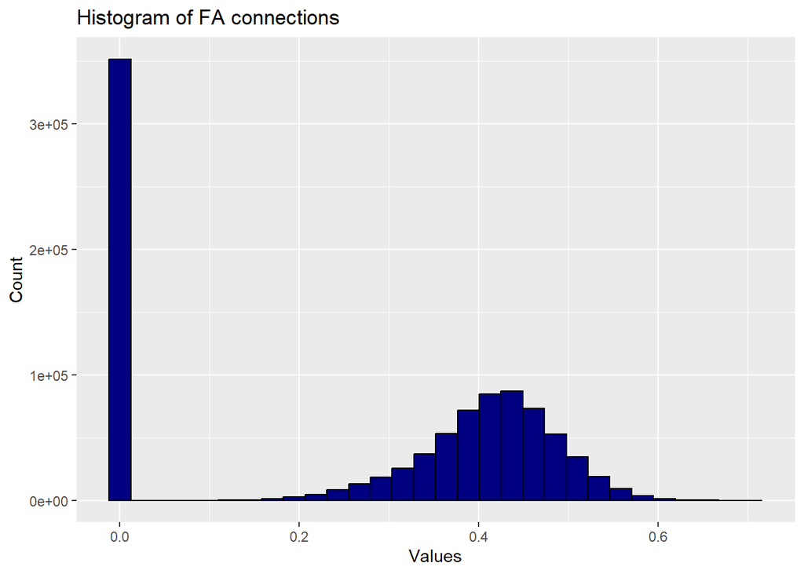

```r
ggsave(filename = "images/FA_hist_before.png", plot = p1, width = 10, height = 7, dpi = 300)
p1
```

## GM MATRICES PROCESSING

Process in GM filtering is the same as in FA, so we repeat same steps in, this case in one chunk of code

```r
HS_all <- HS_60connections(dataDIR, GMDIR, GM_append)

HS_filelist <- paste(HS_subjects, GM_append)

GM_tables <- vector("list", length = length(GM_files)) #allocate space in a vector list
GM_tables <- load_data(dataDIR, GMDIR) ## function load_data defined in helper_functions.R
GM_tables_filtered <- GM_tables #Make a copy to store new values

target_indices<- which(!(GM_files %in% HS_filelist)) # We apply condition only to non-healthy subjects
GM_tables_filtered[target_indices] <- lapply(GM_tables[target_indices], apply_condition, ref_df = HS_all)
```

Repeat process to verify differences

```r
# Compute the difference for each pair of dataframes
diff_list <- mapply(function(df1, df2) {
  # Compute the difference
  diff_df <- df1 - df2
  # Set a threshold for floating point comparison
  threshold <- 1e-6
  # Find indices where the absolute difference is greater than the threshold
  indices <- which(abs(diff_df) > threshold, arr.ind = TRUE)
    # Return the differences if there are any, NULL otherwise
  if(nrow(indices) > 0) {
    return(diff_df[indices])
  } else {
    return(NULL)
  }
}, GM_tables, GM_tables_filtered, SIMPLIFY = FALSE)

# Print the differences
differences <- sum(!sapply(diff_list, is.null))
print(paste("There are differences in", differences, "pairs of dataframes out of", length(GM_tables)))
```

```
## [1] "There are differences in 0 pairs of dataframes out of 165"
```

#### GM VALUE RANGE

Let’s examine the range of values after preprocessing

```r
p2 <- range_values(GM_tables_filtered)
```

```
## [1] "Minimun values is 0 and maximum is 1"
```

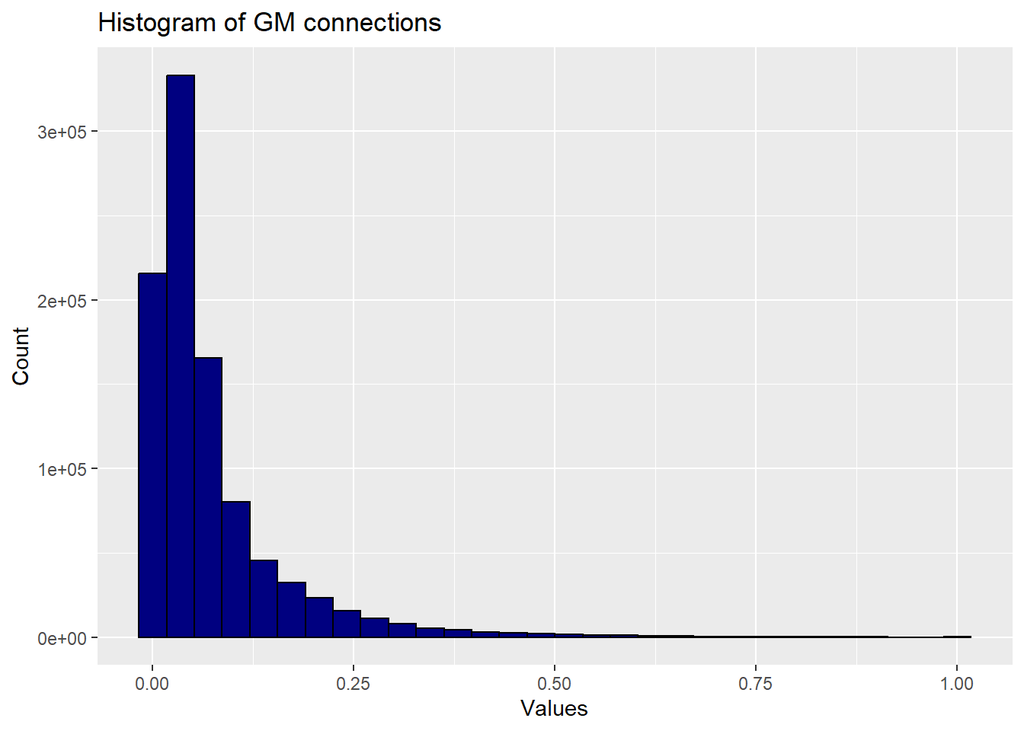

```r
ggsave(filename = "images/GM_hist_before.png", plot = p2, width = 10, height = 7, dpi = 300)
p2
```

## fMRI MATRICES PROCESSING

In these matrices, which represent correlations, we will apply an absolute value function to eliminate negative values while preserving the ‘connection’ between nodes. Additionally, we will set the diagonal to zero, given that their correlation is 1.

Process is simpler than previous matrices

```r
fMRI_tables <- vector("list", length = length(fMRI_files)) #allocate space in a vector list
fMRI_tables_filtered <- fMRI_tables # we do not have to, but this way share same name with other matrices tables and we can compare before and after

#Load matrices and apply absolute value
for(i in seq_along(fMRI_tables)){
  fMRI_tables[[i]] <- read.csv(file.path(dataDIR, fMRIDIR, fMRI_files[i]), header = FALSE)
  fMRI_tables_filtered[[i]] <- sapply(fMRI_tables[[i]], abs)
  diag(fMRI_tables_filtered[[i]]) <- 0
}
```

Examine correlations before and after process, for a given matrix. We will use a HS

```r
HS_matrix<- which(clinical$controls_ms == 0)[1]

png("images/fMRI_corrs_before_after.png")
par(mfrow = c(1,2))

corrplot::corrplot(as.matrix(fMRI_tables[[HS_matrix]]), tl.cex = 1e-50, title = "Before Correction", mar=c(0,0,1,0) )

corrplot::corrplot(as.matrix(fMRI_tables_filtered[[HS_matrix]]), tl.cex = 1e-50, title = "After Correction", mar=c(0,0,1,0))
dev.off()
```

#### fMRI VALUE RANGE

Let’s examine the range of values after preprocessing

```r
p3 <- range_values(fMRI_tables_filtered)
```

```
## [1] "Minimun values is 0 and maximum is 0.984729"
```

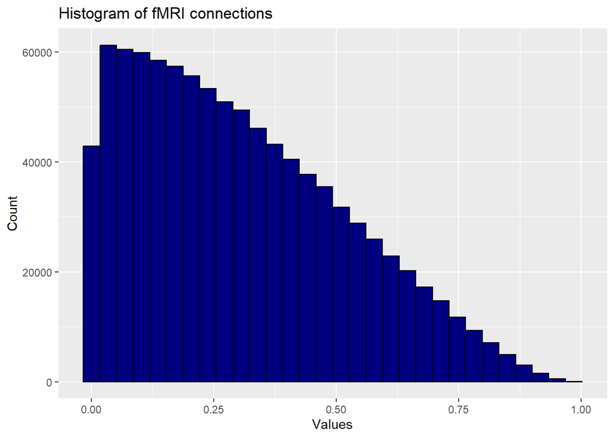

```r
ggsave(filename = "images/fMRI_hist_before.png", plot = p3, width = 10, height = 7, dpi = 300)
p3
```

```r
p <- p1+p2+p3 + plot_layout(ncol = 3, nrow = 1)

ggsave(filename = "images/all_hist_before.png", plot = p, width = 10, height = 7, dpi = 300)
```

## AGE AND SEX CORRECTION

Connectivity changes with age and there are also gender differences. So, we apply a linear regression to avoid the effect of these confounding variables.

```r
# Make tables copies to store corrected data

FA_corrected <- FA_tables_filtered
GM_corrected <- GM_tables_filtered
fMRI_corrected <- fMRI_tables_filtered

#vectors for sex, age and control subjects
sex <- as.factor(clinical$sex)
age <- clinical$age
controls_ms <- as.factor(clinical$controls_ms)

#indices for healthy subjects

HS_indices <- which(controls_ms == 0)


# Use function age_sex_correction defined in helper_functions.R to make the corrections
FA_corrected <- age_sex_correction(FA_tables_filtered, FA_corrected, HS_indices, sex, age)

GM_corrected <- age_sex_correction(GM_tables_filtered, GM_corrected, HS_indices, sex, age)

fMRI_corrected <- age_sex_correction(fMRI_tables_filtered, fMRI_corrected, HS_indices, sex, age)
```

#### RANGE VALUES

```r
p4 <- range_values(FA_corrected)
```

```
## [1] "Minimun values is 0 and maximum is 0.84051723191377"
```

```r
p5 <- range_values(GM_corrected)
```

```
## [1] "Minimun values is 0 and maximum is 1.00000191277537"
```

```r
p6 <- range_values(fMRI_corrected)
```

```
## [1] "Minimun values is 0 and maximum is 1.07968594181291"
```

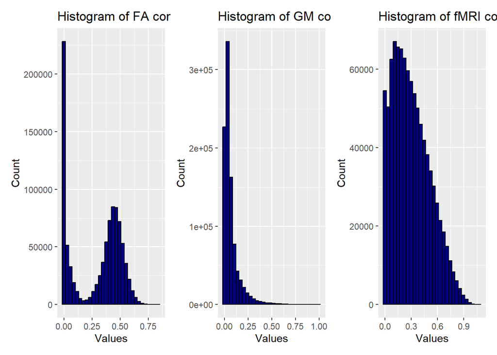

```r
p <- p4+p5+p6 + plot_layout(ncol = 3, nrow = 1)

ggsave(filename = "images/all_hist_after.png", plot = p, width = 10, height = 7, dpi = 300)

p
```

All images

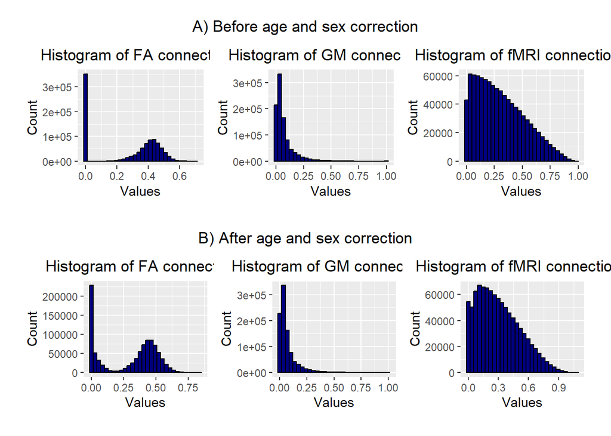

```r
p11 <- (p1 | p2 | p3) +
  plot_annotation(title = "A) Before age and sex correction") &
  theme(plot.title = element_text(hjust = 0.5), plot.tag = element_text(size = 15, face = "bold"))

p12<- (p4 | p5 | p6) +
  plot_annotation(title = "B) After age and sex correction") &
  theme(plot.title = element_text(hjust = 0.5), plot.tag = element_text(size = 15, face = "bold"))

p <- wrap_elements(p11) / wrap_elements(p12)

ggsave(filename = "images/all_hist_weights.png", plot = p, width = 10, height = 7, dpi = 300)

p
```

## SAVE PREPROCESSED DATA

```r
# New Folders
FAnewDIR <- "FA_matrices_c/"
GMnewDIR <- "GM_matrices_c/"
fMRInewDIR <- "fMRI_matrices_c/"

new_csv_append <- "_corrected.csv"

save_data(dataDIR, FAnewDIR, FA_files, FA_corrected, "_corrected.csv", ".csv")

save_data(dataDIR, GMnewDIR, GM_files, GM_corrected, "_corrected.csv", ".csv")

save_data(dataDIR, fMRInewDIR, fMRI_files, fMRI_corrected, "_corrected.csv", ".csv")
```

We still have harmonize data in the corresponding python notebook (Harmonization.ipynb)